# Assignment 3

## Step 1:Install the packages required to perform the analyses

```r
install.packages("tm")
```

```
Error in install.packages : Updating loaded packages
```

```r
library(tm)
install.packages("gmodels")
install.packages("tm")
library(gmodels)
install.packages("SnowballC")
library(SnowballC)
install.packages("wordcloud")
library(wordcloud)
```

## Step 2: Load the training and the test data from the working directory

```r
library(tm)
directory <- getwd()
##Load the data from the source (HAM)
src_ham <- DirSource(directory = "C:\\Users\\Lenovo\\Documents\\train\\ham", encoding = "UTF-8")
sms_corpus_train_ham<- VCorpus(src_ham , readerControl = list(language="lat"))
sms_corpus_train_ham
```

```
<<VCorpus>>
Metadata:  corpus specific: 0, document level (indexed): 0
Content:  documents: 340
```

```r
##Load the data from the source (SPAM)
src_spam <- DirSource(directory = "C:\\Users\\Lenovo\\Documents\\train\\spam", encoding = "UTF-8")
sms_corpus_train_spam <- VCorpus(src_spam, readerControl = list(language="lat"))
sms_corpus_train_spam
```

```
<<VCorpus>>
Metadata:  corpus specific: 0, document level (indexed): 0
Content:  documents: 123
```

## Step 3: Train Data Cleaning

```r
## HAM  Train Data Preparation
# convert to lower case
sms_corpus_train_ham_clean = tm_map(sms_corpus_train_ham, tolower)
# remove digits
sms_corpus_train_ham_clean = tm_map(sms_corpus_train_ham_clean, removeNumbers)
# remove stop words
sms_corpus_train_ham_clean = tm_map(sms_corpus_train_ham_clean, removeWords, stopwords())
# remove punctuation
sms_corpus_train_ham_clean = tm_map(sms_corpus_train_ham_clean, removePunctuation)
# stemming
sms_corpus_train_ham_clean = tm_map(sms_corpus_train_ham_clean, stemDocument)
# removes whitespaces
sms_corpus_train_ham_clean = tm_map(sms_corpus_train_ham_clean, stripWhitespace)
# Plain Text Document
sms_corpus_train_ham_clean <- tm_map(sms_corpus_train_ham_clean, PlainTextDocument)
## SPAM  Train Data Preparation
# convert to lower case
sms_corpus_train_spam_clean = tm_map(sms_corpus_train_spam, tolower)
# remove digits
sms_corpus_train_spam_clean = tm_map(sms_corpus_train_spam_clean, removeNumbers)
# remove stopwords
sms_corpus_train_spam_clean = tm_map(sms_corpus_train_spam_clean, removeWords, stopwords())
# remove punctuation
sms_corpus_train_spam_clean = tm_map(sms_corpus_train_spam_clean, removePunctuation)
# stemming
sms_corpus_train_spam_clean = tm_map(sms_corpus_train_spam_clean, stemDocument)
# removes whitespaces
sms_corpus_train_spam_clean = tm_map(sms_corpus_train_spam_clean, stripWhitespace)
#PlainTextDocument
sms_corpus_train_spam_clean <- tm_map(sms_corpus_train_spam_clean, PlainTextDocument)
sms_corpus_train_clean <-c(sms_corpus_train_spam_clean,sms_corpus_train_ham_clean)
sms_corpus_train_clean
```

```
<<VCorpus>>
Metadata:  corpus specific: 0, document level (indexed): 0
Content:  documents: 463
```

## Visualising the Text Data

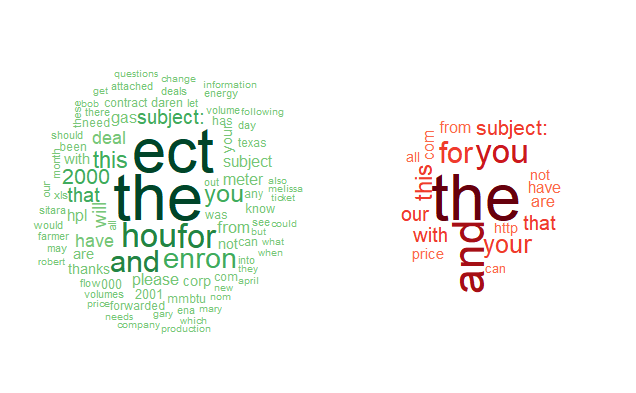

```r
col1 <- brewer.pal(9,"YlGn")
col1 <- col1[-(1:4)]
col2 <- brewer.pal(9,"Reds")
col2 <- col2[-(1:4)]
#min.freq initial settings -> around 10% of the number of docs in the corpus (40 times)
par(mfrow = c(1,2))
wordcloud(sms_corpus_train_ham, min.freq = 50, random.order = FALSE, colors = col1)
wordcloud(sms_corpus_train_spam, min.freq = 50, random.order = FALSE, colors = col2)
```

## Prepare the Test Data same as we did for the Train Data

```r
library(tm)
directory <- getwd()
##Load the data from the source (HAM)
src_ham1 <- DirSource(directory = "C:\\Users\\Lenovo\\Documents\\test\\ham", encoding = "UTF-8")
sms_corpus_test_ham<- VCorpus(src_ham1)
##Load the data from the source (SPAM)
src_spam1 <- DirSource(directory = "C:\\Users\\Lenovo\\Documents\\test\\spam", encoding = "UTF-8")
sms_corpus_test_spam <- VCorpus(src_spam1)
```

## Test Data Cleaning

```r
## HAM Test Data Preparation
# convert to lower case
sms_corpus_test_ham_clean = tm_map(sms_corpus_test_ham, tolower)
# remove digits
sms_corpus_test_ham_clean = tm_map(sms_corpus_test_ham_clean, removeNumbers)
# remove stopwords
sms_corpus_test_ham_clean = tm_map(sms_corpus_test_ham_clean, removeWords, stopwords())
# remove punctuation
sms_corpus_test_ham_clean = tm_map(sms_corpus_test_ham_clean, removePunctuation)
# stemming
sms_corpus_test_ham_clean = tm_map(sms_corpus_test_ham_clean, stemDocument)
# reduces whitespace
sms_corpus_test_ham_clean = tm_map(sms_corpus_test_ham_clean, stripWhitespace)
# Plaintext Document
sms_corpus_test_ham_clean <- tm_map(sms_corpus_test_ham_clean, PlainTextDocument)
## SPAM  Test Data Preparation
# convert to lower case
sms_corpus_test_spam_clean = tm_map(sms_corpus_test_spam, tolower)
# remove digits
sms_corpus_test_spam_clean = tm_map(sms_corpus_test_spam_clean, removeNumbers)
# remove stopwords
sms_corpus_test_spam_clean = tm_map(sms_corpus_test_spam_clean, removeWords, stopwords())
# remove punctuation
sms_corpus_test_spam_clean = tm_map(sms_corpus_test_spam_clean,removePunctuation)
# stemming
sms_corpus_test_spam_clean = tm_map(sms_corpus_test_spam_clean, stemDocument)
# remove whitespaces
sms_corpus_test_spam_clean = tm_map(sms_corpus_test_spam_clean, stripWhitespace)
# Plaintext Document
sms_corpus_test_spam_clean <- tm_map(sms_corpus_test_spam_clean, PlainTextDocument)
sms_corpus_test_clean <- c(sms_corpus_test_spam_clean ,sms_corpus_test_ham_clean)
```

## Use the training datasets to train a Naive Bayes classifier for text classification.

##.Solution: ##Create the document term matrix

```r
train_dtm <- DocumentTermMatrix(sms_corpus_train_clean)
test_dtm <- DocumentTermMatrix(sms_corpus_test_clean)
```

## Finding the frequent terms in training document term matrix and keeping only those words in training and testing data

```r
sms_freq_words <- findFreqTerms(train_dtm,5)
train_freq <- DocumentTermMatrix(sms_corpus_train_clean,list(dictionary=sms_freq_words))
test_freq <- DocumentTermMatrix(sms_corpus_test_clean,list(dictionary=sms_freq_words))
```

## Convert numbers to “yes” and “no”

```r
convert_counts <- function(x){ x <- ifelse(x>0, "YES", "NO")}
train_data <- apply(train_freq, MARGIN = 2, convert_counts)
test_data <- apply(test_freq, MARGIN = 2, convert_counts)
```

## Converting training and test DocumentTermMatrix to data frame’s

```r
train_dataframe <- as.data.frame(train_data)
test_dataframe <- as.data.frame(test_data)
```

## Adding the output variable to the data frame’s

```r
train_type <- rep(c("spam","ham"), times = c(123,340))
train_dataframe <- cbind(train_dataframe,train_type)
test_type <- rep(c("spam","ham"), times = c(130, 348))
test_dataframe <- cbind(test_dataframe, test_type)
```

## Shuffle the records in the dataframe

```r
train_dataframe= train_dataframe[sample(nrow(train_dataframe),replace =FALSE),]
test_dataframe= test_dataframe[sample(nrow(test_dataframe),replace =FALSE),]
```

## Build the training, testing data and training, testing labels

```r
training_data <- train_dataframe[,1:1419]
training_label <- train_dataframe[,1420]
testing_data <- test_dataframe[ , 1:1419]
testing_label <- test_dataframe[ ,1420]
```

## Installing the package “e1071” to run the naive bayes classifier

```r
#install.packages("e1071")
library(e1071)
```

## Building the classifier

```r
sms_email_classifier <- naiveBayes(training_data, training_label)
```

## Make predictions

```r
test_predict <- predict(sms_email_classifier, testing_data)
```

## Evaluating the model performance

```r
library(gmodels)
CrossTable(test_predict, testing_label, prop.chisq = FALSE, prop.t = FALSE,
 dnn = c('predicted', 'actual'))
```

```
   Cell Contents
|-------------------------|
|                       N |
|           N / Row Total |
|           N / Col Total |
|-------------------------|


Total Observations in Table:  478


             | actual
   predicted |       ham |      spam | Row Total |
-------------|-----------|-----------|-----------|
         ham |       324 |         1 |       325 |
             |     0.997 |     0.003 |     0.680 |
             |     0.931 |     0.008 |           |
-------------|-----------|-----------|-----------|
        spam |        24 |       129 |       153 |
             |     0.157 |     0.843 |     0.320 |
             |     0.069 |     0.992 |           |
-------------|-----------|-----------|-----------|
Column Total |       348 |       130 |       478 |
             |     0.728 |     0.272 |           |
-------------|-----------|-----------|-----------|
```